# Network Analysis

## 5.4 Network centrality measures

When exploring a network, we might be interested in finding the most prominent/influential nodes. We already used one measure of vertex centrality - degree centrality - to show more connected characters with bigger nodes and names in the previous plot. However, there are some other centrality measures we can explore, such as **strength**, **closeness**, **betweenness**, and **eigen-centrality**. Please see part 3 for their detailed definitions.

**Strength** of a node in a weighted network is the sum of weights on all edges adjacent to this node. It measures the extent of engagement of a given node with its neighbourhood. The top-10 nodes by strength overlap to a high extent with top-10 by degree.

```r
str = strength(GoT)
head(sort(str, decreasing = TRUE), 10) # top-10 characters by strength
```

```
##       Eddard Stark   Robert Baratheon           Jon Snow   Tyrion Lannister
##               1284                941                784                650
##        Sansa Stark         Bran Stark      Catelyn Stark         Robb Stark
##                545                531                520                516
## Daenerys Targaryen         Arya Stark
##                443                430
```

```r
V(GoT)$strength = strength(GoT) # save as a node attribute
```

**Closeness** centrality measures how many steps, on average, separate one node from any other node. This time, the top-10 list is more different.

```r
cls = closeness(GoT)
head(sort(cls, decreasing = TRUE), 10) # top-10 characters by centrality
```

```
## Robert Baratheon Tyrion Lannister  Jaime Lannister     Eddard Stark
##     0.0005446623     0.0005321980     0.0005313496     0.0005197505
##     Loras Tyrell      Sansa Stark      Janos Slynt    Theon Greyjoy
##     0.0005178664     0.0005165289     0.0005159959     0.0005138746
##    Rodrik Cassel       Arya Stark
##     0.0005128205     0.0005099439
```

```r
V(GoT)$closeness = closeness(GoT) # save as a node attribute
```

**Betweenness** of a node shows how often it lies on the shortest paths between other pairs of nodes. The higher the betweenness, the more crucial the node is in terms of getting or controlling information flow in the network (Luke 2015).

```r
btw = betweenness(GoT)
head(sort(btw, decreasing = TRUE), 10) # top-10 characters by betweenness
```

```
## Robert Baratheon     Eddard Stark Tyrion Lannister       Robb Stark
##         4015.971         3217.925         2634.296         1761.825
##    Catelyn Stark         Jon Snow  Jaime Lannister    Rodrik Cassel
##         1749.579         1553.213         1332.546         1319.278
##            Drogo    Jorah Mormont
##         1186.174         1078.900
```

```r
V(GoT)$betweenness = betweenness(GoT) # save as a node attribute
```

**Eigen-centrality** measures the importance of a node by taking into account the importance of its neighbours. Notice how Varys and Petyr Baelish appear among the top-10 characters.

```r
# the output of eigen_centrality is a list, need to add $vector
eig = eigen_centrality(GoT)$vector
head(sort(eig, decreasing = TRUE), 10) # top-10 characters by eigen-centrality
```

```
##      Eddard Stark  Robert Baratheon  Cersei Lannister       Sansa Stark
##         1.0000000         0.9158179         0.4234363         0.3314489
##     Petyr Baelish     Catelyn Stark Joffrey Baratheon          Jon Snow
##         0.3256606         0.3250923         0.3025768         0.2975685
##             Varys  Tyrion Lannister
##         0.2758104         0.2706707
```

```r
V(GoT)$eigen = eigen_centrality(GoT)$vector
```

Degree and strength are based on the neighbourhood of a vertex and thus are **local** centrality measures. On the other hand, betweenness, closeness, harmonic centrality and eigen-centrality are **global** ones since they account for distances to all other nodes in a network.

Let’s combine all the centrality measures in a data frame and explore correlations between them. Correlations are quite high, except for closeness, where they are moderate. Overlap in centrality measures often happens in many real-world networks (Luke 2015).

```r
options(digits = 3) # decrease the number of digits in the output
centrality = as.data.frame(cbind(deg, cls, btw, str, eig))
cor(centrality)
```

```
##       deg   cls   btw   str   eig
## deg 1.000 0.616 0.871 0.955 0.887
## cls 0.616 1.000 0.550 0.483 0.491
## btw 0.871 0.550 1.000 0.857 0.805
## str 0.955 0.483 0.857 1.000 0.923
## eig 0.887 0.491 0.805 0.923 1.000
```

In addition to betweenness of vertices, we can calculate **betweenness of ties**. Similarly to nodes, edges with high betweenness may have considerable power to control information passing through the network. Related to the edge betweenness are the notions of **cutpoints** and **bridges**. In some cases, only a single edge (a bridge) may exist between several sub-groups in a network, and removing it (making a cutpoint there) will disrupt communication between nodes.

Using `edge_betweenness()` is a bit tricky. If edges have weights, the function will use them by default, however, it will treat them as **distances** though they represent the **strength of a connection**. To adjust for this, we need to specify `weights` argument and pass to it a reciprocal of edge `weight` attribute (DataCamp 2020, *Network Analysis in the Tidyverse*). Otherwise, we will get strange results which we won’t be able to interpret.

```r
E(GoT)$btw.e.w = edge_betweenness(GoT, weights = 1/E(GoT)$weight) # weighted
E(GoT)[head(order(E(GoT)$btw.e.w, decreasing = TRUE),10)] # top-10 connections
```

```
## + 10/684 edges from 097aa65 (vertex names):
##  [1] Eddard Stark      --Robert Baratheon Catelyn Stark     --Eddard Stark
##  [3] Daenerys Targaryen--Robert Baratheon Catelyn Stark     --Tyrion Lannister
##  [5] Eddard Stark      --Jon Snow         Jon Snow          --Tyrion Lannister
##  [7] Bran Stark        --Jon Snow         Daenerys Targaryen--Drogo
##  [9] Jeor Mormont      --Jon Snow         Catelyn Stark     --Robb Stark
```

```r
head(sort(E(GoT)$btw.e.w, decreasing = TRUE),10) # their tie betweenness values
```

```
##  [1] 5257 4519 3465 2865 2773 1900 1149 1084 1084 1058
```

We can also calculate non-weighted edge betweenness - it has weak correlation with weighted betweenness. The latter is a more appropriate measure for us as it accounts for the connection strength.

```r
E(GoT)$btw.e.nw = edge_betweenness(GoT, weights = NA) # use NA to allow non-weighted
cor(E(GoT)$btw.e.w, E(GoT)$btw.e.nw)
```

```
## [1] 0.332
```

We’ll plot our network once more, this time highlighting nodes and edges with high betweenness.

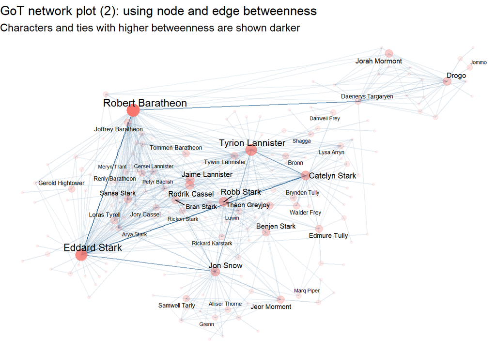

```r
set.seed(55555)
ggraph(GoT, layout = "with_dh") +
  geom_edge_link(aes(alpha = btw.e.w, edge_colour = 1), show.legend = FALSE) +
  geom_node_point(aes(alpha = betweenness, size=betweenness, colour = "red"),
                  show.legend = FALSE) +
  geom_node_text(aes(label = name, filter = betweenness>=300,size=betweenness/3),
                 repel=TRUE, show.legend = FALSE) +
  labs(title = "GoT network plot (2): using node and edge betweenness",
       subtitle = "Characters and ties with higher betweenness are shown darker") +
  theme_void()
```

Now five more edges are highlighted as important ones in our network. Apart from main characters, several other characters such as Jorah Mormont, Drogo, Benjen Stark appear as important ones that join various parts of the network together. The only darker connection is questionable here: the one going from Robert Baratheon right down, to Daenerys. This is because characters never interact (at least in the movie), but only talk about each other.

## 5.5 Community detection

Community detection is an important topic in network analysis since it helps to identify subgroups in a network. Depending on an application, communities may be called *clusters*, *groups*, or *modules*. Similar to clustering, community detection is rather an art than science.

Community detection is be very computationally demanding, especially in large networks. This along with other problems like the absence of an universal definition of community, led to the appearance of a large number of community detection algorithms. The package `igraph` is the most comprehensive one with regard to community detection. It implements various algorithms in the following functions:

- `cluster_label_prop`
- `cluster_edge_betweenness`
- `cluster_walktrap`
- `cluster_fast_greedy`
- `cluster_leading_eigen`
- `cluster_spinglass`
- `cluster_infomap`
- `cluster_louvain`
- `cluster_optimal`

Due to the limitations of this paper, we will not provide descriptions of these algorithms. To read more about each function (algorithm), type `?function_name` in the console.

All these algorithms take a graph as an input and produce a **community object** as an output. By default, the ‘weight’ edge attribute is used as weights if it’s available in the data. To switch it off if necessary, we have to specify `weight = NA`. Similarly to `edge_betweenness`, `cluster_edge_betweenness` interprets weights as distances. To use weights in this clustering algorithm, we need to take their inverses.

To dig into the community object, several functions exist:

- `length()`: to get the number of communities detected by an algorithm
- `sizes()`: to get sizes of each community
- `membership()`: to get community labels per each node.

We will apply all algorithms except `cluster_optimal()` to our data set. The algorithm represents an NP-complete problem and runs in exponential time. According to the documentation, *“Graphs with up to fifty vertices should be fine, graphs with a couple of hundred vertices might be possible”*.

```r
ca.eb = cluster_edge_betweenness(GoT, weights = 1 / E(GoT)$weight); sizes(ca.eb)
```

```
## Community sizes
##  1  2  3  4  5  6  7  8  9 10 11 12 13 14 15
## 12 23 22  3 19  3 40  2 19 17 12  6  3  4  2
```

```r
ca.fg = cluster_fast_greedy(GoT); sizes(ca.fg)
```

```
## Community sizes
##  1  2  3  4  5  6  7
## 26 65 42 26  3 22  3
```

```r
ca.lp = cluster_label_prop(GoT); sizes(ca.lp)
```

```
## Community sizes
##   1   2   3   4   5   6   7   8   9
## 107  22  25  14   6   3   5   3   2
```

```r
ca.le <- cluster_leading_eigen(GoT); sizes(ca.le)
```

```
## Community sizes
##   1   2
## 124  63
```

```r
ca.lou <- cluster_louvain(GoT); sizes(ca.lou)
```

```
## Community sizes
##  1  2  3  4  5  6  7  8
## 22 26 37 30  3 42  3 24
```

```r
ca.wt <- cluster_walktrap(GoT); sizes(ca.wt)
```

```
## Community sizes
##  1  2  3  4  5  6  7  8  9 10 11 12 13 14 15 16 17 18 19 20 21 22 23 24
## 60  3 35  5  3 19 23 19  2  3  2  1  1  1  1  1  1  1  1  1  1  1  1  1
```

```r
ca.sg <- cluster_spinglass(GoT); sizes(ca.sg)
```

```
## Community sizes
##  1  2  3  4  5  6  7  8
## 22 43 22 19 26  3  3 49
```

```r
ca.info <- cluster_infomap(GoT); sizes(ca.info)
```

```
## Community sizes
##  1  2  3  4  5  6  7  8  9 10 11 12 13 14 15
## 60 31 26 22 15  6  5  5  3  3  3  2  2  2  2
```

```r
communities = list(ca.lou, ca.fg, ca.sg, ca.wt, ca.info, ca.eb, ca.lp, ca.le)
alg = c("Louvain","Fast-greedy","Spinglass","Walktrap","InfoMAP","Edge betw.",
"Label.prop.","Lead.eigen.")
len = c(); modul = c()
# loop over communities to calculate their length and modularity
for (i in communities) {
  len = c(len, length(i)) # calculate the number of communities
  modul = c(modul, round(modularity(i),3)) # calculate modularity
}
# create a neat data frame to compare different algorithms
as.data.frame(cbind(alg,len,modul)) %>%
  arrange(desc(modul)) # sort by modularity in descending order
```

| alg | len | modul |
| --- | --- | --- |
| Louvain | 8 | 0.512 |
| Fast-greedy | 7 | 0.51 |
| Walktrap | 24 | 0.488 |
| InfoMAP | 15 | 0.487 |
| Edge betw. | 15 | 0.477 |
| Label.prop. | 9 | 0.413 |
| Lead.eigen. | 2 | 0.316 |
| Spinglass | 8 | 0.058 |

Now that we have generated 8 community (cluster) solutions, the proceeding community will be selected based onthe following: first of all, we can look at modularity: the higher, the better. The *modularity* of a graph measures how good the division of nodes into groups is, or how separated are the different node types from each other, and varies between -0.5 and 1. Communities detected by the majority of algorithms have modularity 0.47 and higher, with Louvain and fast-greedy being at the top of the list and leading eigenvector and spinglass - at the bottom.

Secondly, we can explore how similar the communities detected by different algorithms are. We can compare them using the Rand index. The Rand index is a measure of similarity between two groupings (two cluster solutions) that ranges from 0 to 1. For detail, see https://en.wikipedia.org/wiki/Rand_index.

The function `compare` from the `igraph` package compares two communities at a time. `method = "rand"` will calculate the Rand index, while `method = "adjusted.rand"` will adjust Rand index for the chance grouping of elements. The former produces very high similarity of solutions on our data for 6 out of 8 algorithms (Rand index >= 0.82, not shown here). The latter shows more heterogeneity in communities generated by various algorithms. To get comparisons for all pairs of algorithms, we will run a for loop, save the *adjusted Rand* index in a matrix and visualize it with the `corrplot()` function.

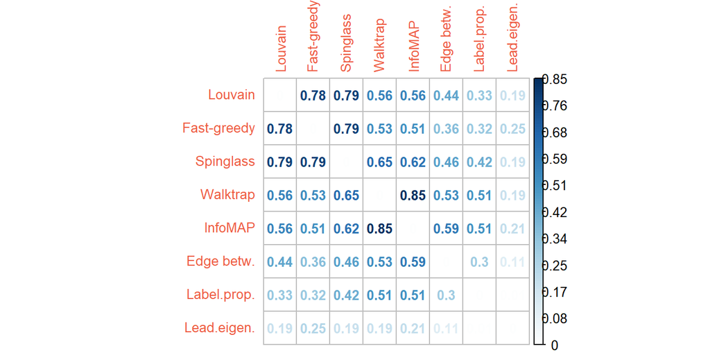

```r
RI = matrix(nrow=8,ncol=8) # initialize a matrix to store the Rand index
for (i in 1:8) {
  for (j in 1:8) {
  RI[i,j] = compare(communities[[i]], communities[[j]], method = "adjusted.rand")
  }
}
rownames(RI) = alg; colnames(RI) = alg; diag(RI) = 0 # set row/col names and diagonal to 0
corrplot(RI, method = "number", is.corr = FALSE, tl.col = "tomato2", tl.cex = 0.8,
         number.cex = 0.8)
```

Surprisingly, *spinglass*, which generated communities with the lowest modularity, produces solutions very similar to those by *louvain* and *fast-greedy* algorithms which rank high by modularity. Also, *walktrap* and *infoMAP* produce very similar solutions, despite having a different number of communities.

Let’s save and visualize communities detected by *Louvain* algorithm. This solution has the highest modularity, produces a reasonable number of communities and is also similar to several other solutions. We will plot communities and edges between them with different colors. However, to color edges with the same colors as nodes, we need to make some data transformations to create edge color attributes.

```r
# TO COLOR EDGES WITH CLUSTER COLORS
# create node data frame with numeric node IDs useful for matching nodes and edges
from = book1 %>% distinct(Source)
to = book1 %>% distinct(Target)
nodes = full_join(from, to, by=c("Source"="Target"))
names(nodes) = "label" # rename the column
nodes = rowid_to_column(nodes, var = "id") # create a column with numeric node IDs
# create a data frame with edges
edges = book1 %>%
  left_join(nodes, by = c("Source" = "label")) %>%  # join "id" for "Source"
  rename(from = id) %>%  # rename "id" that we joined into "from"
  left_join(nodes, by = c("Target" = "label")) %>%  # join "id" for "Target"
  rename(to = id) %>% # rename "id" that we joined into "to"
  select(from, to, weight)
V(GoT)$community = membership(ca.lou) # save louvain community membership
# create edge color attribute: edges within the same community colored as nodes,
# edges between communities having color 9999
# this function requires numeric IDs, does not work with character names
E(GoT)$color <- apply(edges, 1,
                function(x) ifelse(V(GoT)$community[x[1]] == V(GoT)$community[x[2]],
                                   V(GoT)$community[x[1]], 9999))
```

After these long preparations, we can make a plot with communities detected.

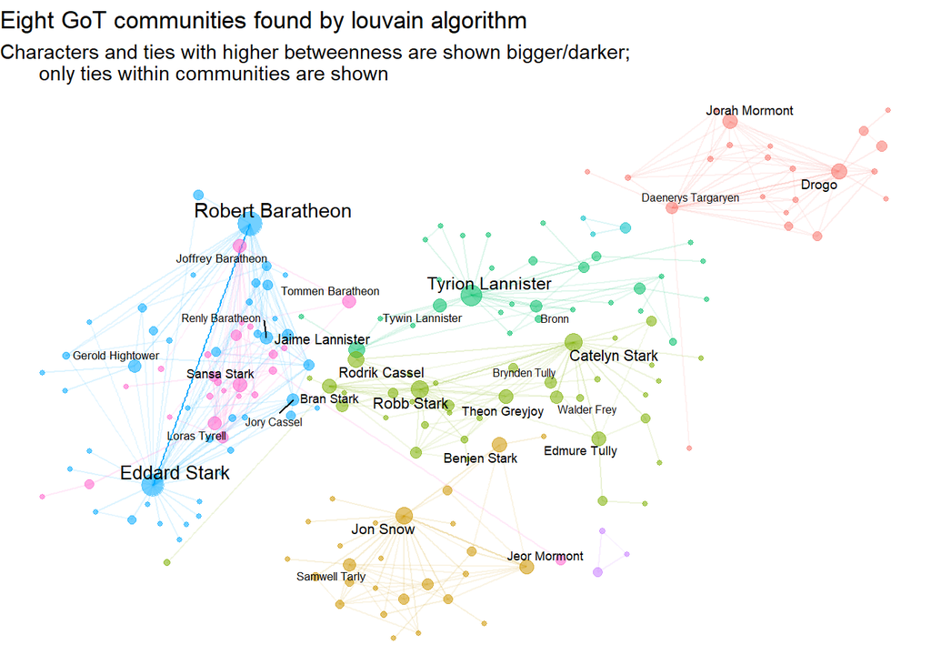

```r
V(GoT)$community = membership(ca.lou)
set.seed(55555)
ggraph(GoT, layout = "with_dh") +
  # we use colour, fill and scale_fill_identity() to color communities in different colors
  # we don't show links between communities with filter=color!=9999
  geom_edge_link(aes(alpha = btw.e.w, color = factor(color), filter=color!=9999),
                 show.legend = FALSE) +
  geom_node_point(aes(alpha = 0.8, size=betweenness, colour = factor(community),
                      fill = factor(community)), show.legend = FALSE) +
  scale_fill_identity() +
  geom_node_text(aes(label = name, filter = betweenness>=500, size=betweenness/3),
                 repel=TRUE, show.legend = FALSE) +
  labs(title = "Eight GoT communities found by louvain algorithm",
       subtitle = "Characters and ties with higher betweenness are shown bigger/darker;
       only ties within communities are shown") +
  theme_void()
```

Cluster analysis results should be interpretable. This refers to community detection as well. Exploring the communities detected shows that they make sense: there is one big community of “the King and his retinues” (Robert Baratheon, Eddard Stark, Cercei, Petyr Baelish etc.) and five smaller ones: “Jon Snow and the North”, “Daenerys and the East”, “Lannisters and their friends”, “Catelyn Stark and her sons”, “Youngsters in King’s Landing”. There are also two triads which we won’t analyse.

Finally, to dig into communities further, we can make an interactive plot. You can play around with it only in **html** version.

```r
V(GoT)$color = V(GoT)$community # create color attribute equal to a cluster number
set.seed(333)
visIgraph(GoT) %>%
  visIgraphLayout(layout = "layout_with_dh") %>%
  # selectedBy = "group" will create a filter with cluster numbers
  visOptions(highlightNearest = TRUE, selectedBy = "group")
```

[interactive chart not shown]

# References

Caporossi, Gilles, and Eglantine Camby. 2017. “Complex Networks Analysis.” Course notes. HEC Montreal.

Csardi, Gabor. 2019. “Package ‘Igraph’.” Web Page. https://cran.r-project.org/web/packages/igraph/igraph.pdf.

DataCamp. 2020. “Network Analysis with R.” Online skill track. https://learn.datacamp.com/skill-tracks/analyzing-networks-with-r.

DataStorm. 2017. “VisNetwork, an R Package for Interactive Network Visualization.” https://datastorm-open.github.io/visNetwork.

Fortunato, Santo. 2009. “Community Detection in Graphs.” Journal Article. *Physics Reports* 486 (2). https://doi.org/10.1016/j.physrep.2009.11.002.

Fortunato, Santo, and Darko Hric. 2016. “Community Detection in Networks: A User Guide.” Journal Article. *Physics Reports* 659 (3). https://doi.org/10.1016/j.physrep.2016.09.002.

Franceschet, Massimo. 2020. “Network Examples.” Web Page. University of Udine. https://users.dimi.uniud.it/~massimo.franceschet/networks/nexus/examples.html.

Ghoshdastidar, Debarghya. 2019. “Statistical Network Analysis.” Web Page. University of Tuebingen. https://bit.ly/3aHtA69.

Hevey, David. 2018. “Network Analysis: A Brief Overview and Tutorial.” Journal Article. *Health Psychology and Behavioral Medicine* 6 (1). https://doi.org/10.1080/21642850.2018.1521283.

Luke, Douglas A. 2015. *A User’s Guide to Network Analysis in R*. Book. New York: Springer-Verlag. http://www.springer.com/9783319238821.

Nagiza F. Samatova, John Jenkins, William Hendrix. 2014. *Practical Graph Mining with R*. Book. United Kingdom: Taylor & Francis. https://www.crcpress.com/Practical-Graph-Mining-with-R/Samatova-Hendrix-Jenkins-Padmanabhan-Chakraborty/p/book/9781439860847.

Sadler, Jesse. 2017. “Introduction to Network Analysis with R. Creating Static and Interactive Network Graphs.” Web Page. https://www.jessesadler.com/post/network-analysis-with-r/.

Wikipedia. 2020. “Graph Theory.” Web Page. https://en.wikipedia.org/wiki/Graph_theory.